# Günlük Coronavirüs Vakaları için LSTM'lerle Zaman Serisi Tahmini

#### Veri dizilerini işlemede, Tekrarlayan Sinir Ağları (LSTM'ler bunlardan biridir) başarılı sonuçlar vermektedir. Bunlar gelecek veya geçmişe dönük olan verileri işlerken verilerdeki kalıpları çok başarılı bir şekilde hatırlayabilirler. Zaman serisi verileri (genellikle) düzenli aralıklarla kaydedilen bir dizi veri noktasını yakalar. Yapılan çalışmalara örnekler vermek gerekirse, günlük hava sıcaklığı, hisse senedi fiyatları ve bir şirketin yaptığı satış sayısı gibi projelerde çok başarılı şekilde kullanılmaktadır.

# Yeni Tip Koronavirüs (COVID-19)

#### 2019 Yılında Çin'in Wuhan eyaletinden çıkarak tüm dünyaya çok hızlı bir şekilde yayılan ve pandemi halini alan Coronavirüs en başta Çin olmak üzere birçok ülkeyi çok derinden etkilemiştir. Avrupa, Amerika, Avustralya gibi kıtalarda da çok hızlı yayılma göstermiştir.

#### Bazı ülkeler verileri şeffaf bir şekilde açıklarken ne yazık ki birçok ülke ölüm, enfekte olmuş hasta ve ağır hasta gibi vakaların verilerini şeffaf bir şekilde paylaşmamıştır.

# Kütüphaneleri Yüklüyoruz

#### Projemize başlarken öncelikle gerekli kütüphaneleri yüklüyoruz. Burada gerekli kütüphaneler bilgisayarımızda yüklü değilse !pip komutu ile kütüphanemizi bilgisayarımıza yüklüyoruz.

#### Eğer bilgisayarınızda yüklü değilse aşağıdaki kütüphaneleri yüklemeniz gerekmektedir.

!pip install -Uq watermark

%reload_ext watermark %watermark -v -p numpy,pandas,torch

```python
import torch
import gdown

import os
import numpy as np
import pandas as pd
from tqdm import tqdm
import seaborn as sns
from pylab import rcParams
import matplotlib.pyplot as plt
from matplotlib import rc
from sklearn.preprocessing import MinMaxScaler
from pandas.plotting import register_matplotlib_converters
from torch import nn, optim

%matplotlib inline
%config InlineBackend.figure_format='retina'

sns.set(style='whitegrid', palette='muted', font_scale=1.2)

HAPPY_COLORS_PALETTE = ["#01BEFE", "#FFDD00", "#FF7D00", "#FF006D", "#93D30C", "#8F00FF"]

sns.set_palette(sns.color_palette(HAPPY_COLORS_PALETTE))

rcParams['figure.figsize'] = 14, 10
register_matplotlib_converters()

RANDOM_SEED = 42
np.random.seed(RANDOM_SEED)
torch.manual_seed(RANDOM_SEED)
```

```
<torch._C.Generator at 0x1d3f0a2dc70>
```

# Günlük Vakalar Veri Kümesi

#### Johns Hopkins Üniversitesi Sistem Bilimi ve Mühendisliği Merkezi (JHU CSSE) tarafından yayınlanmakta olan verilerden faydalanılmıştır. Bu veriler ülkeye göre bildirilen günlük vaka sayısını içermektedir.

#### Veri seti GitHub'da mevcut olan hesabıma yüklenmiş olup projede kullanılmak üzere GitHub hesabımdan çekilmektedir.

#### GitHub Hesabım : https://github.com/imonur/covid19_verisetleri/tree/main/ulkeler/datasetler

# Verilerin Keşfi

#### Verilerimizi GitHub hesabından çekerek sistemimize yüklüyoruz.

```python
df = pd.read_csv('https://raw.githubusercontent.com/imonur/covid19_verisetleri/main/ulkeler/datasetler/zaman_serileri_covid19_ulkeler_dogrulanmis.csv')
df.head()
```

|  | Province/State | Country/Region | Lat | Long | 1/22/20 | 1/23/20 | 1/24/20 | 1/25/20 | 1/26/20 | 1/27/20 | ... | 5/9/22 | 5/10/22 | 5/11/22 | 5/12/22 | 5/13/22 | 5/14/22 | 5/15/22 | 5/16/22 | 5/17/22 | 5/18/22 |
| --- | --- | --- | --- | --- | --- | --- | --- | --- | --- | --- | --- | --- | --- | --- | --- | --- | --- | --- | --- | --- | --- |
| 0 | NaN | Afghanistan | 33.93911 | 67.709953 | 0.0 | 0.0 | 0.0 | 0.0 | 0.0 | 0.0 | ... | 179010.0 | 179017.0 | 179131.0 | 179169.0 | 179203.0 | 179242.0 | 179267.0 | 179321.0 | 179328.0 | 179477.0 |
| 1 | NaN | Albania | 41.15330 | 20.168300 | 0.0 | 0.0 | 0.0 | 0.0 | 0.0 | 0.0 | ... | 275372.0 | 275416.0 | 275440.0 | 275485.0 | 275534.0 | 275574.0 | 275615.0 | 275621.0 | 275688.0 | 275732.0 |
| 2 | NaN | Algeria | 28.03390 | 1.659600 | 0.0 | 0.0 | 0.0 | 0.0 | 0.0 | 0.0 | ... | 265800.0 | 265804.0 | 265806.0 | 265808.0 | 265814.0 | 265816.0 | 265818.0 | 265823.0 | 265828.0 | 265834.0 |
| 3 | NaN | Andorra | 42.50630 | 1.521800 | 0.0 | 0.0 | 0.0 | 0.0 | 0.0 | 0.0 | ... | 41717.0 | 41717.0 | 41717.0 | 42156.0 | 42156.0 | 42156.0 | 42156.0 | 42156.0 | 42156.0 | 42572.0 |
| 4 | NaN | Angola | -11.20270 | 17.873900 | 0.0 | 0.0 | 0.0 | 0.0 | 0.0 | 0.0 | ... | 99287.0 | 99287.0 | 99287.0 | 99287.0 | 99287.0 | 99287.0 | 99287.0 | 99287.0 | 99287.0 | 99287.0 |

5 rows × 852 columns

#### Verilerin yayınlandığı merkezde veriler ülke isimlerine, il, koordinat gibi veriler ile yayınlanmıştır. Biz bu ilk 4 veriyi kullanmayacağımız için bu ilk 4 sütunu kaldırıyoruz.

```python
df = df.iloc[:, 4:]
```

```python
df.head()
```

|  | 1/22/20 | 1/23/20 | 1/24/20 | 1/25/20 | 1/26/20 | 1/27/20 | 1/28/20 | 1/29/20 | 1/30/20 | 1/31/20 | ... | 5/9/22 | 5/10/22 | 5/11/22 | 5/12/22 | 5/13/22 | 5/14/22 | 5/15/22 | 5/16/22 | 5/17/22 | 5/18/22 |
| --- | --- | --- | --- | --- | --- | --- | --- | --- | --- | --- | --- | --- | --- | --- | --- | --- | --- | --- | --- | --- | --- |
| 0 | 0.0 | 0.0 | 0.0 | 0.0 | 0.0 | 0.0 | 0.0 | 0.0 | 0.0 | 0.0 | ... | 179010.0 | 179017.0 | 179131.0 | 179169.0 | 179203.0 | 179242.0 | 179267.0 | 179321.0 | 179328.0 | 179477.0 |
| 1 | 0.0 | 0.0 | 0.0 | 0.0 | 0.0 | 0.0 | 0.0 | 0.0 | 0.0 | 0.0 | ... | 275372.0 | 275416.0 | 275440.0 | 275485.0 | 275534.0 | 275574.0 | 275615.0 | 275621.0 | 275688.0 | 275732.0 |
| 2 | 0.0 | 0.0 | 0.0 | 0.0 | 0.0 | 0.0 | 0.0 | 0.0 | 0.0 | 0.0 | ... | 265800.0 | 265804.0 | 265806.0 | 265808.0 | 265814.0 | 265816.0 | 265818.0 | 265823.0 | 265828.0 | 265834.0 |
| 3 | 0.0 | 0.0 | 0.0 | 0.0 | 0.0 | 0.0 | 0.0 | 0.0 | 0.0 | 0.0 | ... | 41717.0 | 41717.0 | 41717.0 | 42156.0 | 42156.0 | 42156.0 | 42156.0 | 42156.0 | 42156.0 | 42572.0 |
| 4 | 0.0 | 0.0 | 0.0 | 0.0 | 0.0 | 0.0 | 0.0 | 0.0 | 0.0 | 0.0 | ... | 99287.0 | 99287.0 | 99287.0 | 99287.0 | 99287.0 | 99287.0 | 99287.0 | 99287.0 | 99287.0 | 99287.0 |

5 rows × 848 columns

```python
df.isnull().sum().sum()
```

```
3392
```

#### Biz verileri kümülatif olarak inceleyeceğiz. Yani tüm satırları toplayacağız ve bu şekilde kümülatif günlük veri durumunu görmüş olacağız.

```python
daily_cases = df.sum(axis=0)
daily_cases.index = pd.to_datetime(daily_cases.index)
daily_cases.head()
```

```
2020-01-22     556.0
2020-01-23     656.0
2020-01-24     942.0
2020-01-25    1435.0
2020-01-26    2117.0
dtype: float64
```

#### Kümülatif verleri ekrana çizdirelim.

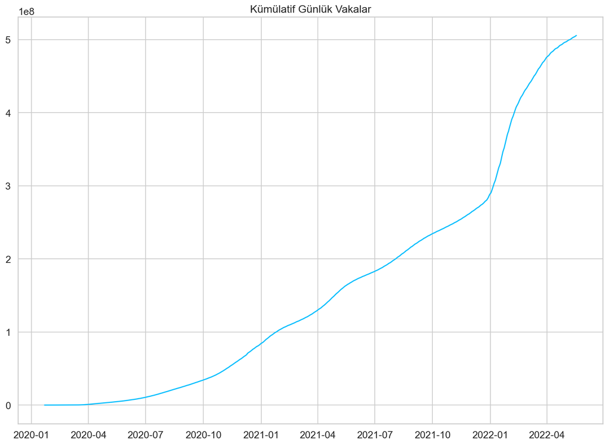

```python
plt.plot(daily_cases)
plt.title("Kümülatif Günlük Vakalar");
```

#### Günlük vakaları inceleyeceğimiz için mevcut değeri bir öncekinden çıkartarak ekrana Günlük verileri çizdireceğiz.

```python
daily_cases = daily_cases.diff().fillna(daily_cases[0]).astype(np.int64)
daily_cases.head()
```

```
2020-01-22    556
2020-01-23    100
2020-01-24    286
2020-01-25    493
2020-01-26    682
dtype: int64
```

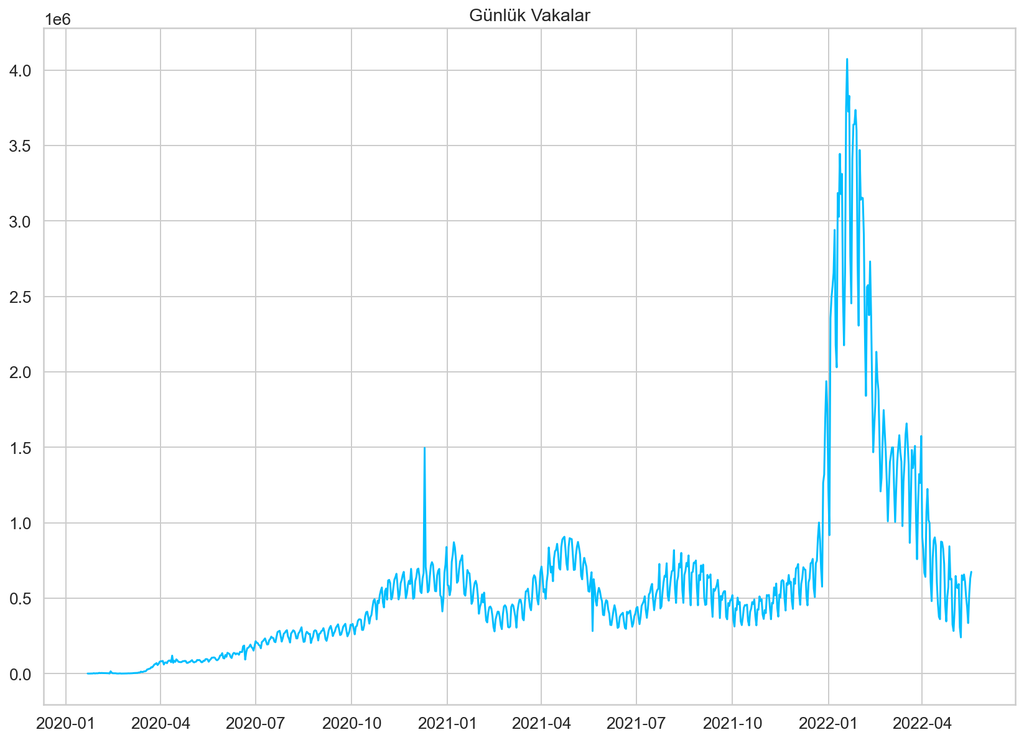

```python
plt.plot(daily_cases)
plt.title("Günlük Vakalar");
```

```python
daily_cases.shape
```

```
(848,)
```

# Ön İşleme

#### Burada verimizi işlerken toplam verinin 748 tanesini eğitim verisi için geriye kalan 100 veriyi ise test verisi için kullanacağız.

```python
test_data_size = 100

train_data = daily_cases[:-test_data_size]
test_data = daily_cases[-test_data_size:]

train_data.shape
```

```
(748,)
```

#### MinMaxScaler kullanarak modelimizin eğitim hızını ve performansını ölçeklendiriyoruz.

```python
scaler = MinMaxScaler()

scaler = scaler.fit(np.expand_dims(train_data, axis=1))

train_data = scaler.transform(np.expand_dims(train_data, axis=1))

test_data = scaler.transform(np.expand_dims(test_data, axis=1))
```

```python
def create_sequences(data, seq_length):
    xs = []
    ys = []

    for i in range(len(data)-seq_length-1):
        x = data[i:(i+seq_length)]
        y = data[i+seq_length]
        xs.append(x)
        ys.append(y)

    return np.array(xs), np.array(ys)
```

```python
seq_length = 7
X_train, y_train = create_sequences(train_data, seq_length)
X_test, y_test = create_sequences(test_data, seq_length)

X_train = torch.from_numpy(X_train).float()
y_train = torch.from_numpy(y_train).float()

X_test = torch.from_numpy(X_test).float()
y_test = torch.from_numpy(y_test).float()
```

#### Her eğitim verimiz, geçmişe ait 7 veri noktasından oluşan bir dizi ve bir etiket değer içermektedir.

```python
X_train.shape
```

```
torch.Size([740, 7, 1])
```

```python
X_train[:2]
```

```
tensor([[[1.1196e-04],
         [0.0000e+00],
         [4.5667e-05],
         [9.6489e-05],
         [1.4289e-04],
         [1.7383e-04],
         [6.2632e-04]],

        [[0.0000e+00],
         [4.5667e-05],
         [9.6489e-05],
         [1.4289e-04],
         [1.7383e-04],
         [6.2632e-04],
         [1.2006e-04]]])
```

```python
y_train.shape
```

```
torch.Size([740, 1])
```

```python
y_train[:2]
```

```
tensor([[0.0001],
        [0.0005]])
```

```python
train_data[:10]
```

```
array([[1.11956734e-04],
       [0.00000000e+00],
       [4.56665624e-05],
       [9.64890270e-05],
       [1.42892147e-04],
       [1.73827560e-04],
       [6.26319359e-04],
       [1.20058866e-04],
       [4.83181693e-04],
       [3.88656819e-04]])
```

# Model Oluşturma

```python
class CoronaVirusTahmini(nn.Module):

  def __init__(self, n_features, n_hidden, seq_len, n_layers=2):
    super(CoronaVirusTahmini, self).__init__()

    self.n_hidden = n_hidden
    self.seq_len = seq_len
    self.n_layers = n_layers

    self.lstm = nn.LSTM(
      input_size=n_features,
      hidden_size=n_hidden,
      num_layers=n_layers,
      dropout=0.5
    )

    self.linear = nn.Linear(in_features=n_hidden, out_features=1)

  def reset_hidden_state(self):
    self.hidden = (
        torch.zeros(self.n_layers, self.seq_len, self.n_hidden),
        torch.zeros(self.n_layers, self.seq_len, self.n_hidden)
    )

  def forward(self, sequences):
    lstm_out, self.hidden = self.lstm(
      sequences.view(len(sequences), self.seq_len, -1),
      self.hidden
    )
    last_time_step = \
      lstm_out.view(self.seq_len, len(sequences), self.n_hidden)[-1]
    y_pred = self.linear(last_time_step)
    return y_pred
```

#### Burada 3 yöntem kullanılıyor. Bunlar:

- Constructor : Yardımcı verileri başlatır ve katmanları oluşturur.
- Reset_hidden_state : Her örnekten sonra durumumuzu sıfırlayacak.
- Forward : Dizileri alıp LSTM katmanından geçirir.

# Eğitim

#### Modelimizin eğitimi için yardımcı bir fonksiyon oluşturuyoruz.

```python
def train_model(
  model,
  train_data,
  train_labels,
  test_data=None,
  test_labels=None
):
  loss_fn = torch.nn.MSELoss(reduction='sum')

  optimiser = torch.optim.Adam(model.parameters(), lr=1e-3)
  num_epochs = 60

  train_hist = np.zeros(num_epochs)
  test_hist = np.zeros(num_epochs)

  for t in range(num_epochs):
    model.reset_hidden_state()

    y_pred = model(X_train)

    loss = loss_fn(y_pred.float(), y_train)

    if test_data is not None:
      with torch.no_grad():
        y_test_pred = model(X_test)
        test_loss = loss_fn(y_test_pred.float(), y_test)
      test_hist[t] = test_loss.item()

      if t % 10 == 0:
        print(f'Epoch {t} train loss: {loss.item()} test loss: {test_loss.item()}')
    elif t % 10 == 0:
      print(f'Epoch {t} train loss: {loss.item()}')

    train_hist[t] = loss.item()

    optimiser.zero_grad()

    loss.backward()

    optimiser.step()

  return model.eval(), train_hist, test_hist
```

#### Modelimizin bir örneğini oluşturup ve onu eğitiyoruz.

```python
model = CoronaVirusTahmini(
  n_features=1,
  n_hidden=512,
  seq_len=seq_length,
  n_layers=2
)
model, train_hist, test_hist = train_model(
  model,
  X_train,
  y_train,
  X_test,
  y_test
)
```

```
Epoch 0 train loss: 26.580974578857422 test loss: 6.058335304260254
Epoch 10 train loss: 12.477336883544922 test loss: 2.841935634613037
Epoch 20 train loss: 15.265148162841797 test loss: 4.173579692840576
Epoch 30 train loss: 15.9932279586792 test loss: 2.2152323722839355
Epoch 40 train loss: 14.331575393676758 test loss: 3.124368667602539
Epoch 50 train loss: 10.767829895019531 test loss: 4.765748023986816
```

#### Şimdi Eğitim ve Test kaybımızı ekrana çizdiriyoruz.

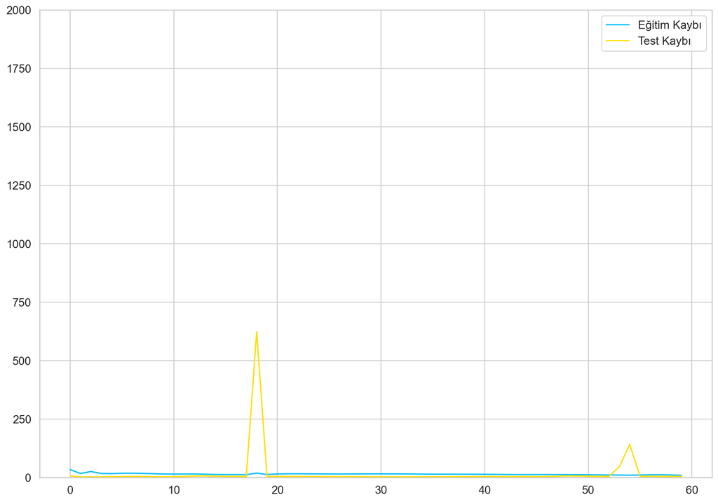

```python
plt.plot(train_hist, label="Eğitim Kaybı")
plt.plot(test_hist, label="Test Kaybı")
plt.ylim((0, 2000))
plt.legend();
```

# Günlük Vaka Tahmini

#### Projemizde modelimiz ileri tarihte sadece bir günü tahmin edecektir. Ancak sonraki günleri tahmin etmek için tahmini değerleri girdi olarak kullanıyoruz.

```python
with torch.no_grad():
  test_seq = X_test[:1]
  preds = []
  for _ in range(len(X_test)):
    y_test_pred = model(test_seq)
    pred = torch.flatten(y_test_pred).item()
    preds.append(pred)
    new_seq = test_seq.numpy().flatten()
    new_seq = np.append(new_seq, [pred])
    new_seq = new_seq[1:]
    test_seq = torch.as_tensor(new_seq).view(1, seq_length, 1).float()
```

```python
true_cases = scaler.inverse_transform(
    np.expand_dims(y_test.flatten().numpy(), axis=0)
).flatten()

predicted_cases = scaler.inverse_transform(
  np.expand_dims(preds, axis=0)
).flatten()
```

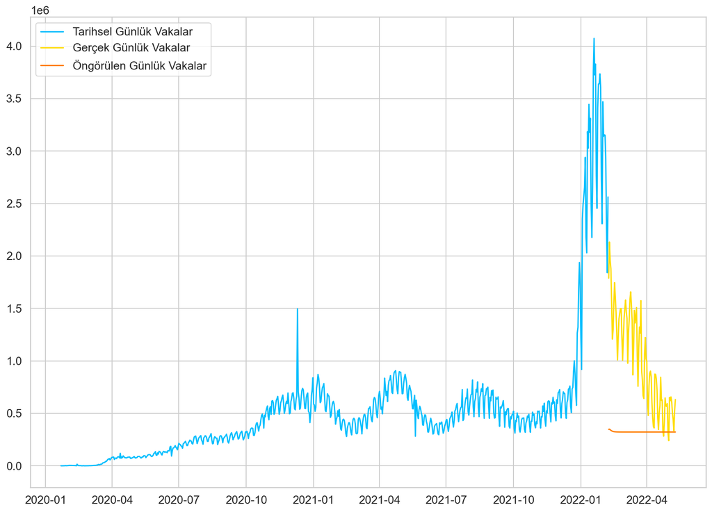

```python
plt.plot(
  daily_cases.index[:len(train_data)],
  scaler.inverse_transform(train_data).flatten(),
  label='Tarihsel Günlük Vakalar'
)

plt.plot(
  daily_cases.index[len(train_data):len(train_data) + len(true_cases)],
  true_cases,
  label='Gerçek Günlük Vakalar'
)

plt.plot(
  daily_cases.index[len(train_data):len(train_data) + len(true_cases)],
  predicted_cases,
  label='Öngörülen Günlük Vakalar'
)

plt.legend();
```

# Tüm Verileri Kullanıyoruz

```python
scaler = MinMaxScaler()

scaler = scaler.fit(np.expand_dims(daily_cases, axis=1))

all_data = scaler.transform(np.expand_dims(daily_cases, axis=1))

all_data.shape
```

```
(848, 1)
```

#### Ön işleme ve eğitim adımları aynıdır.

```python
X_all, y_all = create_sequences(all_data, seq_length)

X_all = torch.from_numpy(X_all).float()
y_all = torch.from_numpy(y_all).float()

model = CoronaVirusTahmini(
  n_features=1,
  n_hidden=512,
  seq_len=seq_length,
  n_layers=2
)
model, train_hist, _ = train_model(model, X_all, y_all)
```

```
Epoch 0 train loss: 33.33379364013672
Epoch 10 train loss: 13.896772384643555
Epoch 20 train loss: 14.478375434875488
Epoch 30 train loss: 14.97703742980957
Epoch 40 train loss: 12.93923282623291
Epoch 50 train loss: 11.151586532592773
```

# Gelecek Vakaları Tahmin Ediyoruz

#### Gelecekteki 15 gün için teyit edilen vakaları tahmin ediyoruz.

```python
DAYS_TO_PREDICT = 15

with torch.no_grad():
  test_seq = X_all[:1]
  preds = []
  for _ in range(DAYS_TO_PREDICT):
    y_test_pred = model(test_seq)
    pred = torch.flatten(y_test_pred).item()
    preds.append(pred)
    new_seq = test_seq.numpy().flatten()
    new_seq = np.append(new_seq, [pred])
    new_seq = new_seq[1:]
    test_seq = torch.as_tensor(new_seq).view(1, seq_length, 1).float()
```

```python
predicted_cases = scaler.inverse_transform(
  np.expand_dims(preds, axis=0)
).flatten()
```

```python
daily_cases.index[-1]
```

```
Timestamp('2022-05-18 00:00:00')
```

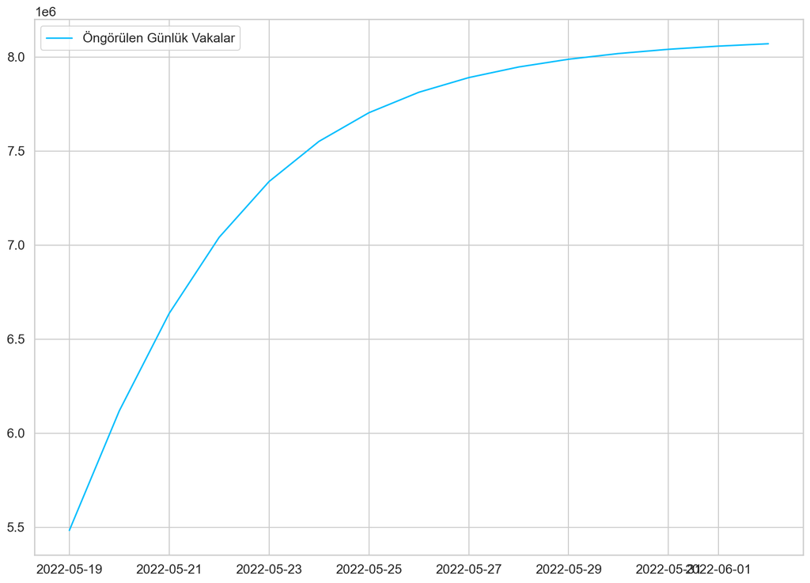

```python
predicted_index = pd.date_range(
  start=daily_cases.index[-1],
  periods=DAYS_TO_PREDICT + 1,
  closed='right'
)

predicted_cases = pd.Series(
  data=predicted_cases,
  index=predicted_index
)

plt.plot(predicted_cases, label='Öngörülen Günlük Vakalar')
plt.legend();
```

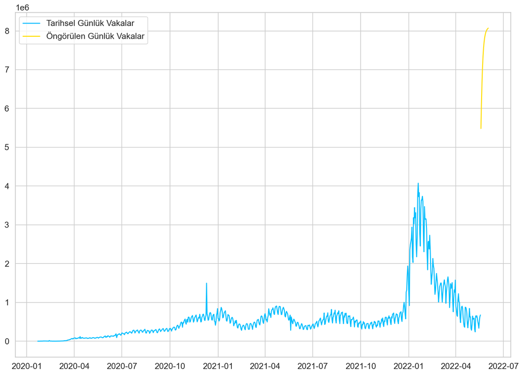

```python
plt.plot(daily_cases, label='Tarihsel Günlük Vakalar')
plt.plot(predicted_cases, label='Öngörülen Günlük Vakalar')
plt.legend();
```